# Foundation of Probability and Statistics Project Fracchia Camilla matr:898235 Salvatori Ilaria matr:898009 Privitera Marta matr:898017

**AIM OF THE ANALYSIS**

The objective of the analysis is to assess the variation of life expectancy in developed and developing countries on the basis of the analyses carried out on the variables of the dataset under consideration.

**DATASET PREPARATION AND CLEANING**

From the website www.kaggle.com has been downloaded the “Life Expectancy” dataset. In order to address the problem of missing values we have used KNIME software and we have changed the NULL values of qualitative variables with moda and the NULL values of quantitative variables with mean.

```r
LifeExpectancyNoMissingData<-read.csv('C:\\Users\\HP\\Desktop\\STATISTICA\\LifeExpectancyNoMissingData.csv', header=TRUE, sep=';')
head(LifeExpectancyNoMissingData)
```

```
##       Country Year     Status Life.expectancy Adult.Mortality infant.deaths
## 1 Afghanistan 2015 Developing            65.0             263            62
## 2 Afghanistan 2014 Developing            59.9             271            64
## 3 Afghanistan 2013 Developing            59.9             268            66
## 4 Afghanistan 2012 Developing            59.5             272            69
## 5 Afghanistan 2011 Developing            59.2             275            71
## 6 Afghanistan 2010 Developing            58.8             279            74
##   Alcohol percentage.expenditure Hepatitis.B Measles  BMI under.five.deaths
## 1    0.01              71.279624          65    1154 19.1                83
## 2    0.01              73.523582          62     492 18.6                86
## 3    0.01              73.219243          64     430 18.1                89
## 4    0.01              78.184215          67    2787 17.6                93
## 5    0.01               7.097109          68    3013 17.2                97
## 6    0.01              79.679367          66    1989 16.7               102
##   Polio Total.expenditure Diphtheria HIV.AIDS       GDP Population
```

[output cut: 20 more lines]

Subsequently, through the use of Python software, it was decided to focus the analysis only on the year 2014, without considering the changes in the phenomenon that have occurred over the years.In addition, the original dataset has been divided on the basis of the variable ‘Status’: in this way, two separate tables have been obtained containing respectively one data concerning developed countries, the other data on developing countries.

**ANALISI PRELIMINARI**

- DATASET DEVELOPED

```r
developed_tot<-read.csv('C:\\Users\\HP\\Desktop\\STATISTICA\\developed_2014.csv', header=TRUE, sep=',')
developed_tot$row.ID<-NULL #per non leggere la colonna rowId
head(developed_tot)
```

```
##     Country Year    Status Life.expectancy Adult.Mortality infant.deaths
## 1 Australia 2014 Developed            82.7               6             1
## 2   Austria 2014 Developed            81.4              66             0
## 3   Belgium 2014 Developed            89.0              76             0
## 4  Bulgaria 2014 Developed            74.3             138             1
## 5    Canada 2014 Developed            82.0              65             2
## 6   Croatia 2014 Developed            77.8              97             0
##   Alcohol percentage.expenditure Hepatitis.B Measles  BMI under.five.deaths
## 1    9.71             10769.3630          91     340 66.1                 1
## 2   12.32              8350.1935          98     117 57.1                 0
## 3   12.60              7163.3489          98      70 63.4                 1
## 4   12.03               153.1400          95       0 65.1                 1
## 5    8.10               102.1902          55     418 66.4                 2
## 6   12.14              1884.0988          95       0 63.1                 0
##   Polio Total.expenditure Diphtheria HIV.AIDS        GDP Population
```

[output cut: 20 more lines]

```r
tail(developed_tot)
```

```
##                                                 Country Year    Status
## 33                                             Slovenia 2014 Developed
## 34                                                Spain 2014 Developed
## 35                                               Sweden 2014 Developed
## 36                                          Switzerland 2014 Developed
## 37 United Kingdom of Great Britain and Northern Ireland 2014 Developed
## 38                             United States of America 2014 Developed
##    Life.expectancy Adult.Mortality infant.deaths Alcohol percentage.expenditure
## 33            87.0              76             0   10.46               31.13493
## 34            82.6              58             1    0.01               42.98848
## 35            82.3              54             0    7.30             1142.21240
## 36            83.2              51             0    9.61            19479.91161
## 37            81.0              71             3   10.37                0.00000
## 38            79.1              14            23    8.82                0.00000
##    Hepatitis.B Measles  BMI under.five.deaths Polio Total.expenditure
```

[output cut: 20 more lines]

Through the functions *head( )* and *tail( )* it is possible to visually synthesize the dataset, in order to observe only the first 6 rows and the last 6 rows of the table.

```r
str(developed_tot)
```

```
## 'data.frame':    38 obs. of  22 variables:
##  $ Country                        : chr  "Australia" "Austria" "Belgium" "Bulgaria" ...
##  $ Year                           : int  2014 2014 2014 2014 2014 2014 2014 2014 2014 2014 ...
##  $ Status                         : chr  "Developed" "Developed" "Developed" "Developed" ...
##  $ Life.expectancy                : num  82.7 81.4 89 74.3 82 77.8 83 78.6 84 77.3 ...
##  $ Adult.Mortality                : num  6 66 76 138 65 97 53 88 73 122 ...
##  $ infant.deaths                  : int  1 0 0 1 2 0 0 0 0 0 ...
##  $ Alcohol                        : num  9.71 12.32 12.6 12.03 8.1 ...
##  $ percentage.expenditure         : num  10769 8350 7163 153 102 ...
##  $ Hepatitis.B                    : num  91 98 98 95 55 ...
##  $ Measles                        : int  340 117 70 0 418 0 10 222 27 0 ...
##  $ BMI                            : num  66.1 57.1 63.4 65.1 66.4 63.1 59.8 65.6 58.4 59.4 ...
##  $ under.five.deaths              : int  1 0 1 1 2 0 0 0 0 0 ...
##  $ Polio                          : num  92 98 99 88 91 95 99 99 94 93 ...
##  $ Total.expenditure              : num  9.42 11.21 1.59 8.44 1.45 ...
##  $ Diphtheria                     : num  92 98 99 88 91 95 99 97 94 93 ...
##  $ HIV.AIDS                       : num  0.1 0.1 0.1 0.1 0.1 0.1 0.1 0.1 0.1 0.1 ...
##  $ GDP                            : num  62215 51323 47439 7853 544 ...
##  $ Population                     : num  2346694 8541575 112957 7223938 35544564 ...
##  $ thinness..1.19.years           : num  0.6 1.8 1 1.9 0.5 1.5 0.9 1.8 1.1 1.9 ...
##  $ thinness.5.9.years             : num  0.6 2 1 1.9 0.5 1.5 1 1.9 0.9 1.9 ...
##  $ Income.composition.of.resources: num  936 892 0.89 787 912 ...
##  $ Schooling                      : num  20.4 15.9 16.3 14.8 15.9 ...
```

Using the function *str( )* we obtain in the output the characteristics of the dataframe, which reports 38 observations on 22 variables. In addition, the class to which the column indices belong and some values associated with each variable are highlighted.

**Scatter plot of developed countries**

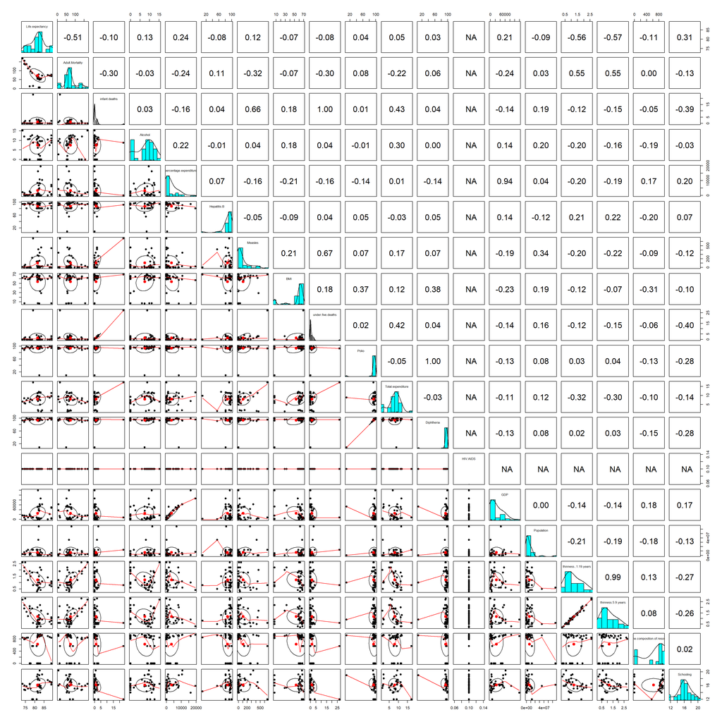

```r
library(psych)
pairs.panels(developed_tot[,4:22], pch = 19)
```

The same steps are repeated to carry out a preliminary analysis of the dataset concerning developing countries.

```r
developing_tot<-read.csv('C:\\Users\\HP\\Desktop\\STATISTICA\\developing_2014.csv', header=TRUE, sep=',')
developing_tot$row.ID<-NULL
head(developing_tot)
```

```
##               Country Year     Status Life.expectancy Adult.Mortality
## 1         Afghanistan 2014 Developing            59.9             271
## 2             Albania 2014 Developing            77.5               8
## 3             Algeria 2014 Developing            75.4              11
## 4              Angola 2014 Developing            51.7             348
## 5 Antigua and Barbuda 2014 Developing            76.2             131
## 6           Argentina 2014 Developing            76.2             118
##   infant.deaths Alcohol percentage.expenditure Hepatitis.B Measles  BMI
## 1            64    0.01               73.52358          62     492 18.6
## 2             0    4.51              428.74907          98       0 57.2
## 3            21    0.01               54.23732          95       0 58.4
## 4            67    8.33               23.96561          64   11699 22.7
## 5             0    8.56             2422.99977          99       0 47.0
## 6             8    7.93              847.37175          94       1 62.2
##   under.five.deaths Polio Total.expenditure Diphtheria HIV.AIDS        GDP
```

[output cut: 20 more lines]

```r
str(developing_tot)
```

```
## 'data.frame':    145 obs. of  22 variables:
##  $ Country                        : chr  "Afghanistan" "Albania" "Algeria" "Angola" ...
##  $ Year                           : int  2014 2014 2014 2014 2014 2014 2014 2014 2014 2014 ...
##  $ Status                         : chr  "Developing" "Developing" "Developing" "Developing" ...
##  $ Life.expectancy                : num  59.9 77.5 75.4 51.7 76.2 76.2 74.6 72.5 75.4 76.8 ...
##  $ Adult.Mortality                : num  271 8 11 348 131 118 12 119 16 7 ...
##  $ infant.deaths                  : int  64 0 21 67 0 8 1 5 0 0 ...
##  $ Alcohol                        : num  0.01 4.51 0.01 8.33 8.56 7.93 3.91 0.01 9.45 1.57 ...
##  $ percentage.expenditure         : num  73.5 428.7 54.2 24 2423 ...
##  $ Hepatitis.B                    : num  62 98 95 64 99 94 93 94 96 98 ...
##  $ Measles                        : int  492 0 0 11699 0 1 13 0 0 46 ...
##  $ BMI                            : num  18.6 57.2 58.4 22.7 47 62.2 54.1 51.5 63.8 62.9 ...
##  $ under.five.deaths              : int  86 1 24 101 0 9 1 6 0 0 ...
##  $ Polio                          : num  58 98 95 68 96 92 95 97 96 98 ...
##  $ Total.expenditure              : num  8.18 5.88 7.21 3.31 5.54 4.79 4.48 6.4 7.74 4.98 ...
##  $ Diphtheria                     : num  62 98 95 64 99 94 93 94 96 98 ...
##  $ HIV.AIDS                       : num  0.1 0.1 0.1 2 0.2 0.1 0.1 0.1 0.1 0.1 ...
##  $ GDP                            : num  613 4576 548 479 12888 ...
##  $ Population                     : num  327582 288914 39113313 2692466 12753375 ...
##  $ thinness..1.19.years           : num  17.5 1.2 6 8.5 3.3 1 2.1 2.8 2.5 6.1 ...
##  $ thinness.5.9.years             : num  17.5 1.3 5.8 8.3 3.3 0.9 2.1 2.9 2.5 6 ...
##  $ Income.composition.of.resources: num  476 761 741 527 782 825 739 752 789 0.82 ...
##  $ Schooling                      : num  10 14.2 14.4 11.4 13.9 17.3 12.7 12.2 12.6 14.5 ...
```

**Scatter plot of developing countries**

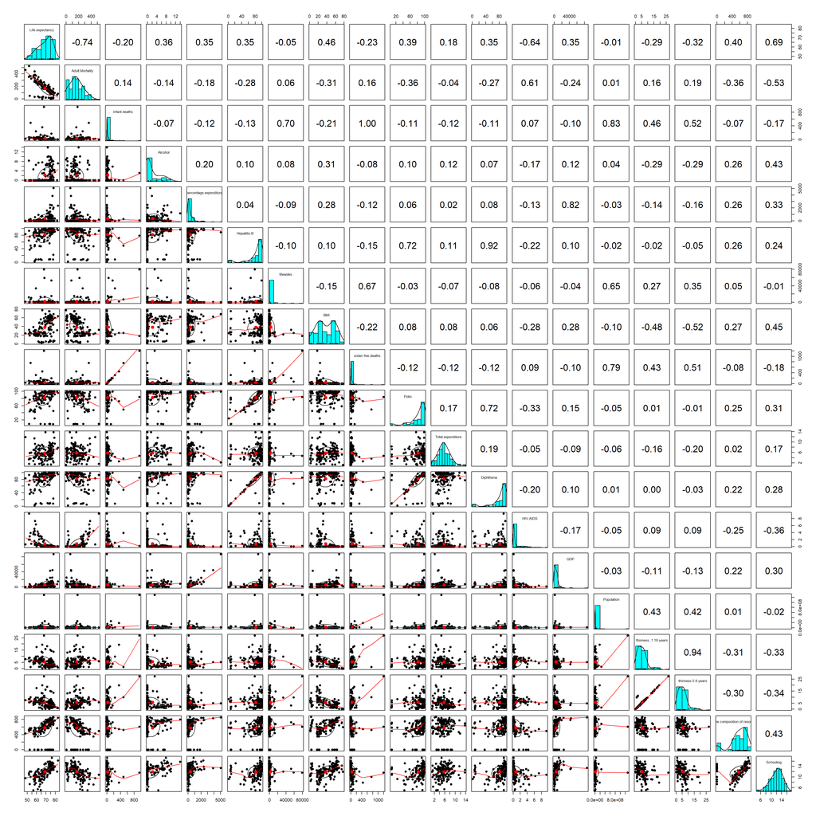

```r
library(psych)
pairs.panels(developing_tot[,4:22], pch = 19)
```

In addition to the predictable correlations already set out for the developed countries, which also apply to the developing countries, we can. make some interesting observations:

**PROCEEDING WITH THE DESCRIPTIVE ANALYSIS**

To carry out the main descriptive analyses of our interest, we have focused on three variables in particular: “life expectancy”, “adult mortality” and “alchol”. This was possible through the creation of a new dataset containing only these three variables, respectively for developed and developing countries.

- DEVELOPED COUNTRIES

```r
developed<-read.csv('C:\\Users\\HP\\Desktop\\STATISTICA\\regression_developed.csv', header=TRUE, sep=',')
head(developed)
```

```
##     Country Life.expectancy Adult.Mortality Alcohol
## 1 Australia            82.7               6    9.71
## 2   Austria            81.4              66   12.32
## 3   Belgium            89.0              76   12.60
## 4  Bulgaria            74.3             138   12.03
## 5    Canada            82.0              65    8.10
## 6   Croatia            77.8              97   12.14
```

We focus on the descriptive analysis of the quantitative variables of this dataset using the *summary( )* command:

```r
summary(developed[,2:4])
```

```
##  Life.expectancy Adult.Mortality     Alcohol
##  Min.   :73.40   Min.   :  6.00   Min.   : 0.010
##  1st Qu.:78.72   1st Qu.: 56.25   1st Qu.: 3.480
##  Median :81.85   Median : 66.50   Median : 8.945
##  Mean   :81.50   Mean   : 73.79   Mean   : 7.528
##  3rd Qu.:82.97   3rd Qu.: 78.75   3rd Qu.:10.740
##  Max.   :89.00   Max.   :169.00   Max.   :15.190
```

From a quick observation it can be seen that the average and median life expectancy in developed countries are almost the same. From this we can say that the average is not affected by the presence of outliers. For the variable “alchol”, however, a deviation of the mean from the median is evident, even if not particularly heavy.

**Analysis of media property**

We verify that the property of the mean is respected for which the value of the arithmetic mean is greater than that geometry and the harmonic one. By running the code you can see how the property A <G <x is respected, where x is the arithmetic mean and is positive.

```r
#geometric mean
G<- function(x){(prod(x))^(1/n)}
n<-nrow(developed)
G(developed$Life.expectancy)
```

```
## [1] 81.39606
```

```r
G(developed$Adult.Mortality)
```

```
## [1] 60.83693
```

```r
G(developed$Alcohol)
```

```
## [1] 2.132668
```

```r
#harmonic mean
A<-function(x){mean(1/x)^-1}
A(developed$Life.expectancy)
```

```
## [1] 81.28921
```

```r
A(developed$Adult.Mortality)
```

```
## [1] 39.70379
```

```r
A(developed$Alcohol)
```

```
## [1] 0.04727362
```

```r
#developed$Life.expectancy
A(developed$Life.expectancy)
```

```
## [1] 81.28921
```

```r
G(developed$Life.expectancy)
```

```
## [1] 81.39606
```

```r
mean(developed$Life.expectancy)
```

```
## [1] 81.50263
```

```r
#developed$Adult.Mortality
A(developed$Adult.Mortality)
```

```
## [1] 39.70379
```

```r
G(developed$Adult.Mortality)
```

```
## [1] 60.83693
```

```r
mean(developed$Adult.Mortality)
```

```
## [1] 73.78947
```

```r
#developed$Alcohol
A(developed$Alcohol)
```

```
## [1] 0.04727362
```

```r
G(developed$Alcohol)
```

```
## [1] 2.132668
```

```r
mean(developed$Alcohol)
```

```
## [1] 7.527632
```

**Range of variation** We evaluate the range of variation of the variables of interest, keeping in mind that it is an extremely sensitive value to the influence of outliers.

```r
x_min<-min(developed$Life.expectancy)
x_max<-max(developed$Life.expectancy)
range_life_expectancy<-x_max-x_min
range_life_expectancy
```

```
## [1] 15.6
```

```r
x_min_1<-min(developed$Adult.Mortality)
x_max_1<-max(developed$Adult.Mortality)
range_adult_mortality<-x_max_1-x_min_1
range_adult_mortality
```

```
## [1] 163
```

```r
x_min_2<-min(developed$Alcohol)
x_max_2<-max(developed$Alcohol)
range_alcohol<-x_max_2-x_min_2
range_alcohol
```

```
## [1] 15.18
```

**IQR** Indicates the amplitude of the range that contains 50% of the observations (between Q1 and Q3). It is a more robust measure of variability in the range and therefore more reliable in the presence of outliers.

```r
quantile(developed$Life.expectancy)[2]
```

```
##    25%
## 78.725
```

```r
quantile(developed$Life.expectancy)[4]
```

```
##    75%
## 82.975
```

```r
quantile(developed$Adult.Mortality)[2]
```

```
##   25%
## 56.25
```

```r
quantile(developed$Adult.Mortality)[4]
```

```
##   75%
## 78.75
```

```r
quantile(developed$Alcohol)[2]
```

```
##  25%
## 3.48
```

```r
quantile(developed$Alcohol)[4]
```

```
##   75%
## 10.74
```

```r
IQR(developed$Life.expectancy)
```

```
## [1] 4.25
```

```r
IQR(developed$Adult.Mortality)
```

```
## [1] 22.5
```

```r
IQR(developed$Alcohol)
```

```
## [1] 7.26
```

- DEVELOPING COUNTRIES

The same steps are repeated to carry out a preliminary analysis of the dataset concerning developing countries.The calculations relating to compliance with the propriety of the average are not repeated, since they were previously carried out for illustrative purposes only.

```r
developing<-read.csv('C:\\Users\\HP\\Desktop\\STATISTICA\\regression_developing.csv', header=TRUE, sep=',')
head(developing)
```

```
##               Country Life.expectancy Adult.Mortality Alcohol
## 1         Afghanistan            59.9             271    0.01
## 2             Albania            77.5               8    4.51
## 3             Algeria            75.4              11    0.01
## 4              Angola            51.7             348    8.33
## 5 Antigua and Barbuda            76.2             131    8.56
## 6           Argentina            76.2             118    7.93
```

```r
summary(developing [,2:4])
```

```
##  Life.expectancy Adult.Mortality    Alcohol
##  Min.   :48.10   Min.   :  1.0   Min.   : 0.010
##  1st Qu.:63.80   1st Qu.: 93.0   1st Qu.: 0.010
##  Median :70.00   Median :155.0   Median : 0.010
##  Mean   :68.92   Mean   :168.3   Mean   : 2.165
##  3rd Qu.:74.80   3rd Qu.:237.0   3rd Qu.: 4.030
##  Max.   :83.00   Max.   :522.0   Max.   :13.940
```

Compared to what is observed for developed countries, here we note a greater deviation of the average from the median both for the variable “Life expectancy”, and for the variable “Alchol”. Through the boxplots, it will then be possible to understand if actually in this case there is a greater incidence of outliers.

**Range of variation**

```r
x_MIN<-min(developing$Life.expectancy)
x_MAX<-max(developing$Life.expectancy)
x_MAX-x_MIN
```

```
## [1] 34.9
```

```r
x_MIN_1<-min(developing$Adult.Mortality)
x_MAX_1<-max(developing$Adult.Mortality)
x_MAX_1-x_MIN_1
```

```
## [1] 521
```

```r
x_MIN_2<-min(developing$Alcohol)
x_MAX_2<-max(developing$Alcohol)
x_MAX_2-x_MIN_2
```

```
## [1] 13.93
```

**IQR**

```r
IQR(developing$Life.expectancy)
```

```
## [1] 11
```

```r
IQR(developing$Adult.Mortality)
```

```
## [1] 144
```

```r
IQR(developing$Alcohol)
```

```
## [1] 4.02
```

The values seen so far, both for developed countries and for developing countries, will be useful for us to build the box blots of the variables involved. In particular, observing these data you can already imagine what will be the appearance of the boxplot reported later.

**How the box plots will appear?**

**Variabile Alchol**: In developed countries an IQR of 7.26 is observed, higher than the IQR of developing countries which is equal to 4.02. From this observation it can be said that the box of developed countries will be wider than that of developing countries.Moreover, there is a big difference in the Median (equal to. 8.94 in developed countries and 0.01 in developing countries), thanks to which we can say that the box of developed countries will be higher in the box plot than that of developing countries, which will indeed be crushed towards the minimum values (also because the minimum observed value is 0.01). In addition, it is interesting to note that the averages of developed and developing countries are respectively 7,528 and 2,165, but they are within two ranges not particularly different ( 15,18 for developed countries and 13,93 for developing countries). From these observations, it can therefore be assumed that the distribution of alchol consumption in developing countries is affected by the presence of outliers (Arabic countries and Russia).

**BOXPLOT**

- LIFE EXPECTANCY

```r
developed_developing<-read.csv('C:\\Users\\HP\\Desktop\\STATISTICA\\developed&developing.csv', header=TRUE, sep=',')
head(developed_developing)
```

```
##     Country Year    Status Life.expectancy Adult.Mortality infant.deaths
## 1 Australia 2014 Developed            82.7               6             1
## 2   Austria 2014 Developed            81.4              66             0
## 3   Belgium 2014 Developed            89.0              76             0
## 4  Bulgaria 2014 Developed            74.3             138             1
## 5    Canada 2014 Developed            82.0              65             2
## 6   Croatia 2014 Developed            77.8              97             0
##   Alcohol percentage.expenditure Hepatitis.B Measles  BMI under.five.deaths
## 1    9.71             10769.3630          91     340 66.1                 1
## 2   12.32              8350.1935          98     117 57.1                 0
## 3   12.60              7163.3489          98      70 63.4                 1
## 4   12.03               153.1400          95       0 65.1                 1
## 5    8.10               102.1902          55     418 66.4                 2
## 6   12.14              1884.0988          95       0 63.1                 0
##   Polio Total.expenditure Diphtheria HIV.AIDS        GDP Population
```

[output cut: 20 more lines]

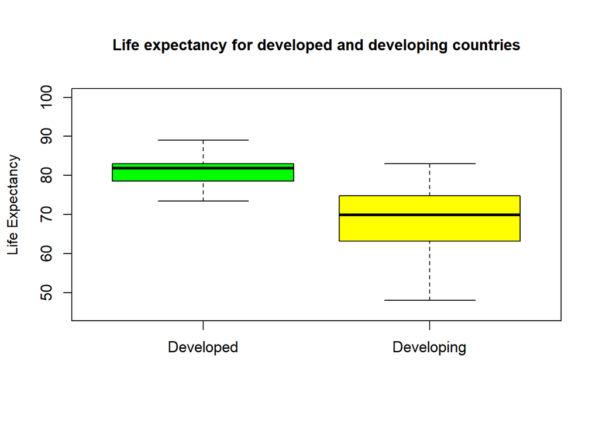

```r
options(repr.plot.width=1,repr.plot.height=40,repr.plot.res=100)
par(mar = c(5, 3, 4, 1) + 1.2)
boxplot(developed_developing$Life.expectancy ~ developed_developing$Status, ylab = "Life Expectancy",xlab = "",col=c("green","yellow"), main="Life expectancy for developed and developing countries",cex.main=1.1, cex.names=1.1,cex.axis=1.1,ylim=c(45,100),cex.lab=1.0,cex.main=1.0)
```

- ALCHOL

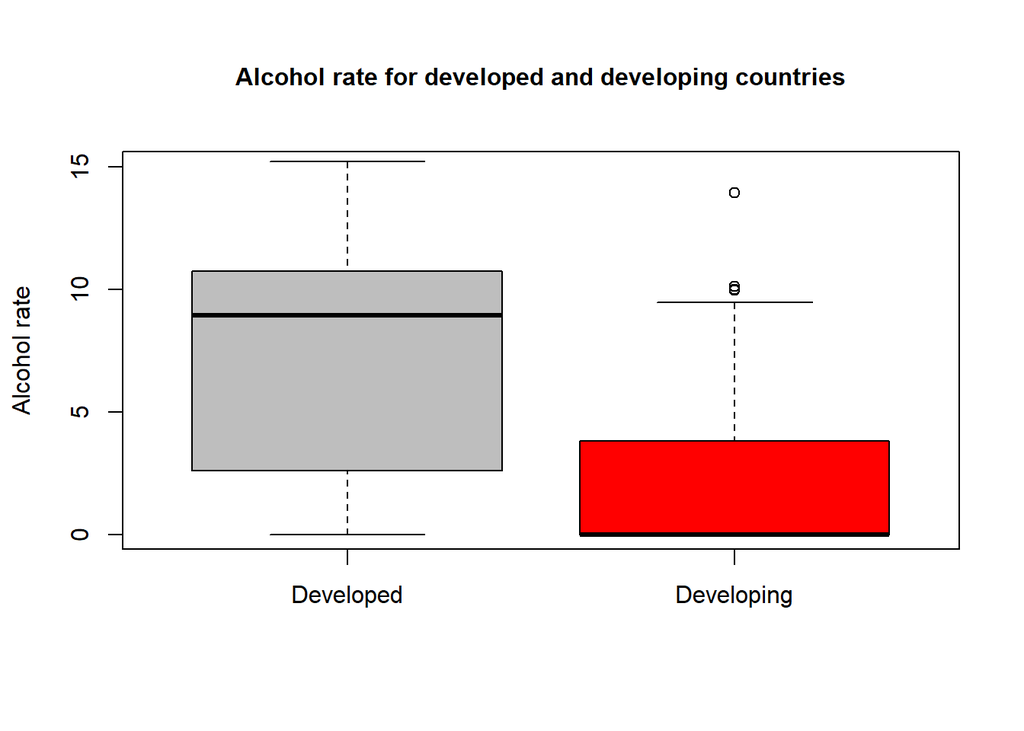

```r
options(repr.plot.width=10,repr.plot.height=12,repr.plot.res=100)
par(mar = c(5, 3, 4, 1) + 1.2)
boxplot(developed_developing$Alcohol~ developed_developing$Status, ylab = "Alcohol rate",xlab = "",col=c("grey","red"), main="Alcohol rate for developed and developing countries",cex.names=1.0,cex.axis=1.0,ylim=c(0,15),cex.lab=1.0,cex.main=1.0)
```

Looking at the boxplots we can therefore say that the hypothesis made with the preliminary data are correct.

**Variance**

It measures the deviation of observations from their average

```r
my_var<-function(x){mean(x^2)-(mean(x)^2)}

#developed
sigma_2_life_expectancy<-my_var(developed$Life.expectancy)
sigma_2_adult_mortality<-my_var(developed$Adult.Mortality)
sigma_2_alcohol<-my_var(developed$Alcohol)

sigma_2_life_expectancy
```

```
## [1] 17.32973
```

```r
sigma_2_adult_mortality
```

```
## [1] 1398.798
```

```r
sigma_2_alcohol
```

```
## [1] 21.05198
```

```r
#developing
sigma_2_life_expectancy_developing<-my_var(developing$Life.expectancy)
sigma_2_adult_mortality_developing<-my_var(developing$Adult.Mortality)
sigma_2_alcohol_developing<-my_var(developing$Alcohol)

sigma_2_life_expectancy_developing
```

```
## [1] 54.59676
```

```r
sigma_2_adult_mortality_developing
```

```
## [1] 11887.87
```

```r
sigma_2_alcohol_developing
```

```
## [1] 10.07484
```

**Standard deviation**

```r
sqrt(sigma_2_life_expectancy)
```

```
## [1] 4.162899
```

```r
sqrt(sigma_2_adult_mortality)
```

```
## [1] 37.40051
```

```r
sqrt(sigma_2_alcohol)
```

```
## [1] 4.588243
```

```r
sqrt(sigma_2_life_expectancy_developing)
```

```
## [1] 7.388962
```

```r
sqrt(sigma_2_adult_mortality_developing)
```

```
## [1] 109.0315
```

```r
sqrt(sigma_2_alcohol_developing)
```

```
## [1] 3.174089
```

**Covariance** We calculate it to measure the strength of the relationship between x (life expectancy) and y (Alcohol)

```r
my_cov<-function(x,y){(mean(x*y))-(mean(x)*mean(y))}
my_cov(developed$Life.expectancy, developed$Alcohol)
```

```
## [1] 2.449348
```

```r
my_cov(developing$Life.expectancy, developing$Alcohol)
```

```
## [1] 8.344832
```

Also through a quick look at the standard deviations of the variables “Alchol” and “Life expectancy”, we can see that the relationship is respected whereby: -s(x)s(y) <=COV(x,y) <= s(x)s(y)

**Correlation Coefficient** To correctly interpret the value of covariance, the correlation coefficient must be calculated, which allows the normalization of covariance. Thanks to the correlation coefficient, it is also possible to establish or not the existence of a linear relationship.

```r
cor(developed$Life.expectancy, developed$Alcohol)
```

```
## [1] 0.1282355
```

```r
cor(developing$Life.expectancy, developing$Alcohol)
```

```
## [1] 0.3558075
```

In both cases the value of the correlation coefficient is greater than 0. Therefore, it can be said that there is a positive association between the two variables considered.

**Dependency** We can now calculate the $\eta^{2}$ to assess the dependency on average between the variables *Life.expectancy* and *Status*.

```r
devLE=var(developed_developing$Life.expectancy)*length(developed_developing$Life.expectancy)
LED=developed_developing[developed_developing$Status=="Developed",]$Life.expectancy
LEUD=developed_developing[developed_developing$Status=="Developing",]$Life.expectancy
devEN=var(LED)*length(LED)+var(LEUD)*length(LEUD)
#il rapporto di correlazione è uguale a:
round(1-devEN/devLE,3)
```

```
## [1] 0.369
```

```r
devLE=var(developed_developing$Alcohol)*length(developed_developing$Alcohol)
LED=developed_developing[developed_developing$Status=="Developed",]$Alcohol
LEUD=developed_developing[developed_developing$Status=="Developing",]$Alcohol
devEN=var(LED)*length(LED)+var(LEUD)*length(LEUD)
#il rapporto di correlazione è uguale a:
round(1-devEN/devLE,3)
```

```
## [1] 0.283
```

**Contingency table** We compute the Contingency Table relating to *Life.expectancy* and *Status* and the corresponding $\chi^{2}$. In agreement with what has been observed until now between these two variables we find also a dependence on distribution. The two variables mutually influence each other. In fact $\chi^{2}$ is positive and significantly different from 0.

```r
developing<-read.csv('C:\\Users\\HP\\Desktop\\STATISTICA\\regression_developing.csv', header=TRUE, sep=',')
developed<-read.csv('C:\\Users\\HP\\Desktop\\STATISTICA\\regression_developed.csv', header=TRUE, sep=',')

#developed$Life.expectancy
breaks <- c(50, 60, 70, 75, 80, 85)
developed_life <- cut(developed$Life.expectancy, breaks=breaks)
freq_abs_developed <- table(developed_life)

#developing$Life.expectancy
breaks <- c(50, 60, 70, 75, 80, 85)
developing_life <- cut(developing$Life.expectancy, breaks=breaks)
freq_abs_developing<- table(developing_life)

#tablefreq
tablefreq<-rbind(freq_abs_developed,freq_abs_developing)

#summary(tablefreq)
tab_rel<-prop.table(tablefreq)

#addmargins(tablefreq)
addmargins(tab_rel)
```

```
##                       (50,60]   (60,70]    (70,75]    (75,80]    (80,85]
## freq_abs_developed  0.0000000 0.0000000 0.02272727 0.03977273 0.11931818
## freq_abs_developing 0.1363636 0.2727273 0.21590909 0.18181818 0.01136364
## Sum                 0.1363636 0.2727273 0.23863636 0.22159091 0.13068182
##                           Sum
## freq_abs_developed  0.1818182
## freq_abs_developing 0.8181818
## Sum                 1.0000000
```

```r
#il comando prop.table consente di calcolare le frequenze condizionate relative cioè divide ciascuna frequenza assoluta in tab per la frequenza marginale corrispondente
#prop.table(tablefreq,1) #distribuzione di ciascuna classe condizionata all'esito (y|x)
#prop.table(tablefreq,2) #distribuzione di ciascun esito condizionato alla classe (x|y)


n<-sum(tablefreq)

f_rel<-tablefreq/n

f_x<-apply(f_rel,1,sum)
f_y<-apply(f_rel,2,sum)
array1<-c(f_x)

array2<-c(f_y)


f_e<-outer(f_x,f_y)

chiquadro_normalized<-(sum(f_rel^2/f_e)-1)
chiquadro_normalized
```

```
## [1] 0.5726529
```

The *prop.table( )* command allows you to calculate the relative conditional frequencies ie divides each absolute frequency in tabs by the corresponding marginal frequency. If we wanted to observe the distribution of each conditioned class at the result or vice versa, we would have to use the following commands: *prop.table(tablefreq,1)* and *prop.table(tablefreq,2)*

**HISTOGRAMS** In the following section we present the two distribution of *Life.expectancy* and *Alcohol* variables. We compare the two distributions with the corresponding Normal distribution.

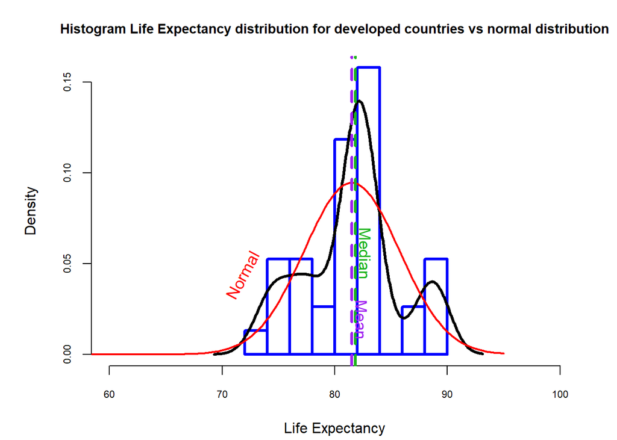

```r
options(repr.plot.width=15,repr.plot.height=10,repr.plot.res=130)

par(mar = c(3, 4, 2, 1) + 1.2,lwd=3)
h<-hist(developed$Life.expectancy,main='Histogram Life Expectancy distribution for developed countries vs normal distribution',cex.main=0.9,col='white',border='blue',freq=FALSE, xlab='Life Expectancy',xlim=c(60,100),cex.axis=0.7)
lines(density(developed$Life.expectancy,col='blue',lwd=2))
x=seq(35,95,length.out=200)
f=dnorm(x,mean=mean(developed$Life.expectancy),sd=sd(developed$Life.expectancy))
lines(x,f,col='red',lwd=2)
abline(v=median(developed$Life.expectancy),col=rgb(0.1,0.7,0.1), lwd=3, lty=2)
abline(v=mean(developed$Life.expectancy), col="purple", lwd=3, lty=2)
text("Mean", x = mean(developed$Life.expectancy), y = 0.03, srt = -90, pos = 4,cex=1.1,col='purple')
text("Median", x = median(developed$Life.expectancy), y = 0.07, srt = -90, pos = 4,cex=1.1,col=rgb(0.1,0.7,0.1))
text("Normal", x = 70, y = 0.031, srt = 62, pos = 4,cex=1.1,col="red")
```

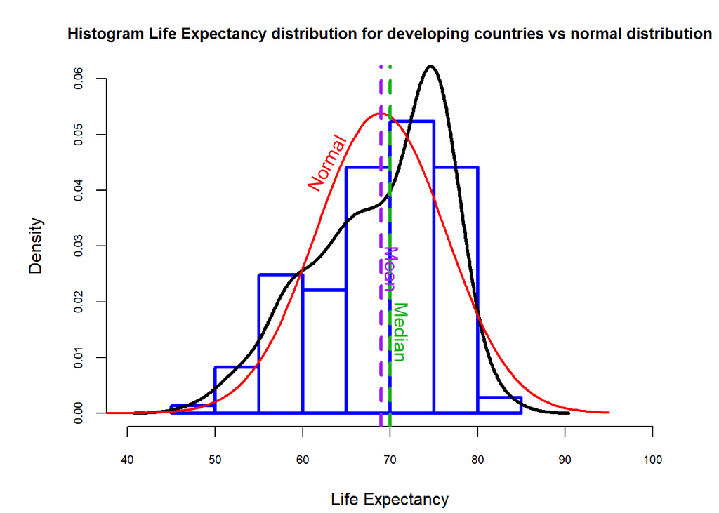

```r
options(repr.plot.width=15,repr.plot.height=10,repr.plot.res=130)

par(mar = c(3, 4, 2, 1) + 1.2,lwd=3)
h<-hist(developing$Life.expectancy,main='Histogram Life Expectancy distribution for developing countries vs normal distribution',cex.main=0.9,col='white',border='blue',freq=FALSE, xlab='Life Expectancy',xlim=c(40,100),ylim=c(0,0.06),cex.axis=0.7)
lines(density(developing$Life.expectancy,col='blue',lwd=2))
x=seq(35,95,length.out=200)
f=dnorm(x,mean=mean(developing$Life.expectancy),sd=sd(developing$Life.expectancy))
lines(x,f,col='red',lwd=2)
abline(v=median(developing$Life.expectancy),col=rgb(0.1,0.7,0.1), lwd=3, lty=2)
abline(v=mean(developing$Life.expectancy), col="purple", lwd=3, lty=2)
text("Mean", x = mean(developing$Life.expectancy),y = 0.03, srt = -90, pos = 4,cex=1.1,col='purple')
text("Median", x = median(developing$Life.expectancy), y = 0.02, srt = -90, pos = 4,cex=1.1,col=rgb(0.1,0.7,0.1))
text("Normal", x = 60, y = 0.04, srt = 62, pos = 4,cex=1.1,col="red")
```

From the previous graphs we notice that in developed countries the distribution of *Life.expectancy* does not present peculiar asymmetry while in developing countries we note a significant negative asymmetry. The symmetry and the asymmetry are detected by calculating the Pearson asymmetry index with the *skewness* function.

```r
library(moments)
skewness(developed$Life.expectancy)
```

```
## [1] 0.00939963
```

```r
skewness(developing$Life.expectancy)
```

```
## [1] -0.6007781
```

```r
library(moments)
kurtosis(developed$Life.expectancy)
```

```
## [1] 2.609958
```

```r
kurtosis(developing$Life.expectancy)
```

```
## [1] 2.498633
```

**LINEAR REGRESSION MODEL**

The need to construct a linear regression model arises from the desire to investigate whether the ‘alcohol rate’ can be a significant variable in order to explain the development of ‘life expectancy’. In this regard, a model has been created in which the regressive factor is the alcohol content in developed (and after in developing countries), while the one to be explained is the life expectancy in these countries.

- Deveoped countries

```r
y<-developed$Life.expectancy
x<-developed$Alcohol

mod1<-lm(y~x, data=developed)
summary(mod1)
```

```
##
## Call:
## lm(formula = y ~ x, data = developed)
##
## Residuals:
##     Min      1Q  Median      3Q     Max
## -8.9941 -3.1342  0.3494  2.0382  7.3493
##
## Coefficients:
##             Estimate Std. Error t value Pr(>|t|)
## (Intercept)  80.6268     1.3221  60.985   <2e-16 ***
## x             0.1163     0.1500   0.776    0.443
## ---
## Signif. codes:  0 '***' 0.001 '**' 0.01 '*' 0.05 '.' 0.1 ' ' 1
##
## Residual standard error: 4.242 on 36 degrees of freedom
## Multiple R-squared:  0.01644,    Adjusted R-squared:  -0.01088
## F-statistic: 0.6019 on 1 and 36 DF,  p-value: 0.4429
```

Finally, the R2 of the model, that is the statistical indicator that explains how much variability of the variable response is explained by the variable independent is very low, equal to : 0.01644: only 1.64% of the variance of y (‘life expectancy’) is explained by x (‘alcol rate’).

So based on the available data, we accept the null hypothesis that beta is equal to 0, So we accept the hypothesis that in developed countries alcohol consumption is not a variable that significantly affects life expectancy: the latter is influenced more by other variables.

We then look for another variable that can significantly affect life expectancy: what would seem to be such is the ‘mortality rate of adults’.

```r
y<-developed$Life.expectancy
f<-developed$Adult.Mortality

mod_bis<-lm(y~f, data=developed)
summary(mod_bis)
```

```
##
## Call:
## lm(formula = y ~ f, data = developed)
##
## Residuals:
##     Min      1Q  Median      3Q     Max
## -7.7022 -2.3717 -0.4752  0.4024  7.7358
##
## Coefficients:
##             Estimate Std. Error t value Pr(>|t|)
## (Intercept) 85.68182    1.32113  64.855  < 2e-16 ***
## f           -0.05664    0.01597  -3.546  0.00111 **
## ---
## Signif. codes:  0 '***' 0.001 '**' 0.01 '*' 0.05 '.' 0.1 ' ' 1
##
## Residual standard error: 3.682 on 36 degrees of freedom
## Multiple R-squared:  0.2589, Adjusted R-squared:  0.2383
## F-statistic: 12.58 on 1 and 36 DF,  p-value: 0.001105
```

The defect of this model is that again the R2 is low (0.2589), that is the variable ‘Mortality rate’ explains only 26% of the total varibility of life expectancy. This is justified by the fact that life is influenced by innumerable variables, while here only one is analyzed.

**Graphs of the two models**

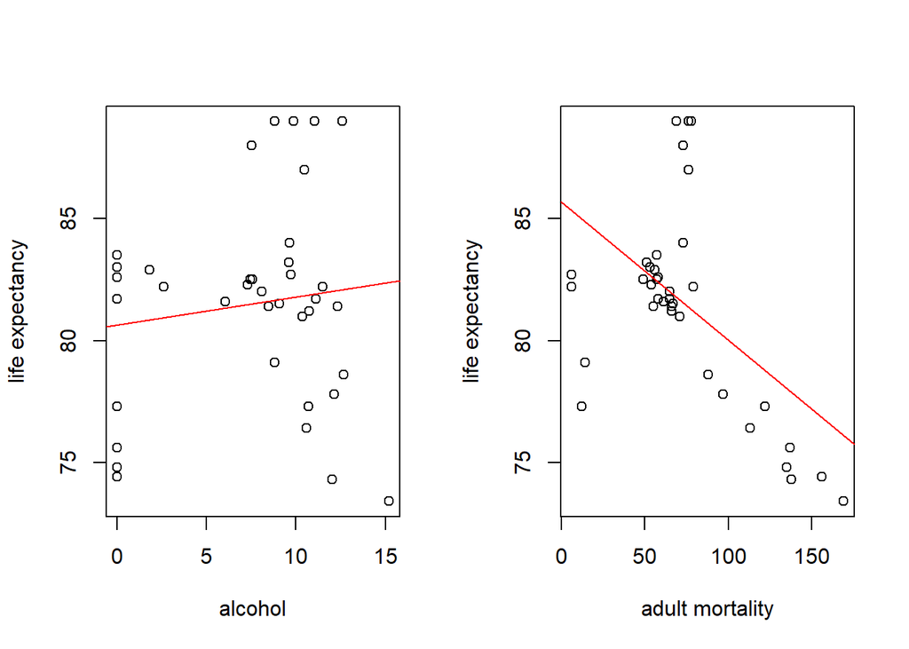

```r
par(mfrow=c(1,2))
plot(x, y, ylab = "life expectancy", xlab="alcohol")
abline(lm(y ~ x), col = "red")

plot(f, y, ylab = "life expectancy", xlab="adult mortality")
abline(lm(y ~ f), col = "red")
```

Graphically we confirm what highlighted by the models: - the first graph shows substantially the absence of sigificativeness: the observations are scattered in the graph and not oriented along the line - the second graph shows an improvement in the estimate, even if the observations are not made along the regression line (evidence that R2 is low)

For exercise and completeness (whit what has been done in the course) we attach the estimate of the linear regression model between the variable ‘life expectancy’ and ‘alcohol rate’ built manually, without the command R and then also the hypothesis test,

```r
#beta=cov(x,y)/var(x)
cov_x_y<-my_cov(developed$Life.expectancy, developed$Alcohol)
var_x<-my_var(developed$Life.expectancy)
beta_hat<-cov_x_y/var_x

#alpha=y media- beta (x media)
mean(y)
```

```
## [1] 81.50263
```

```r
mean(x)
```

```
## [1] 7.527632
```

```r
alpha_hat<-mean(y)-(beta_hat*mean(x))
```

**Hypothesis test** H0: beta=0 vs H1:beta!= 0 We want to verify the significance of the parameters estimated with the linear regression model (model: life expectancy~alcohol)

```r
a<-0.001 #level of significance
b_2<-coef(mod1)[[2]] #extraction of the second coefficient of the model (slope)
se_b_2<-sqrt(vcov(mod1)[2,2]) #extraction the square root of the variance of beta from the 'variance-covariance matrix'
df<- df.residual(mod1) #degrees of freedom
t1<-b_2/se_b_2 #statistic test observed
tc1<-qt(1-a/2, df) #critic value
t1;tc1
```

```
## [1] 0.7758183
```

```
## [1] 3.58215
```

```r
a #level of significance
```

```
## [1] 0.001
```

```r
b_1<-coef(mod1)[[1]] #extraction of the first coefficient of the model (intercept)
se_b_1<-sqrt(vcov(mod1)[1,1]) #extraction the square root of the variance of beta from the 'variance-covariance matrix'
df<- df.residual(mod1) #degrees of freedom
t1<-b_1/se_b_1 #statistic test observed
tc1<-qt(1-a/2, df) #critic value
t1;tc1
```

```
## [1] 60.98502
```

```
## [1] 3.58215
```

First test: we do not refuse the null hypothesis that the beta coefficient is equal to 0 (so it is not significant), because the t absolute value is lower than the t crical value. Second test: we rject the null hypothesis that the alpha coefficient is equal to 0 (so it is significant), because the t absolute value is grater than t critical value.

- Developing countries We replicate the same regression model for the developing countries:

```r
y1<-developing$Life.expectancy
x1<-developing$Alcohol

mod2<-lm(y1~x1, data=developing)
summary(mod2)
```

```
##
## Call:
## lm(formula = y1 ~ x1, data = developing)
##
## Residuals:
##      Min       1Q   Median       3Q      Max
## -22.3312  -4.0398   0.8602   5.4961  14.8602
##
## Coefficients:
##             Estimate Std. Error t value Pr(>|t|)
## (Intercept)  67.1315     0.6990  96.039  < 2e-16 ***
## x1            0.8283     0.1819   4.553 1.12e-05 ***
## ---
## Signif. codes:  0 '***' 0.001 '**' 0.01 '*' 0.05 '.' 0.1 ' ' 1
##
## Residual standard error: 6.954 on 143 degrees of freedom
## Multiple R-squared:  0.1266, Adjusted R-squared:  0.1205
## F-statistic: 20.73 on 1 and 143 DF,  p-value: 1.123e-05
```

In this model the alcohol content is significant in the distribution of y ‘life expectancy’ and with a slight positive influence. (We reject the null hypothesis that beta is equal to zero -H0:beta=0- and the fact that it is not significant). This seems to be a questionable conclusion, but it may be justified in two aspects, the first one is about technical issue: since the choice of do not eliminate outliers, justified by the desire to maintain the representativeness of the data (the outliers in fact concern countries with substantially opposite cultures: these are the Arab countries that by culture prohibit the consumption of alcoholic beverages and Russia that has a long tradition of consumption and production of alcoholic beverages). The second aspect, on the other hand, concerns a socio-demographic component: in truly poor countries alcohol appears to be a secondary energy source in daily calorie consumption, so even if in developed countries it is known to be harmful from a health point of view, In developing countries or countries where the negative health components are very different, the food use of alcohol can be a component of survival.

```r
y1<-developing$Life.expectancy
f1<-developing$Adult.Mortality

mod2_bis_bis<-lm(y1~f1, data=developing)
summary(mod2_bis_bis)
```

```
##
## Call:
## lm(formula = y1 ~ f1, data = developing)
##
## Residuals:
##      Min       1Q   Median       3Q      Max
## -22.2135  -1.9222   0.6291   3.6072   9.7933
##
## Coefficients:
##              Estimate Std. Error t value Pr(>|t|)
## (Intercept) 77.372373   0.763708  101.31   <2e-16 ***
## f1          -0.050188   0.003808  -13.18   <2e-16 ***
## ---
## Signif. codes:  0 '***' 0.001 '**' 0.01 '*' 0.05 '.' 0.1 ' ' 1
##
## Residual standard error: 5 on 143 degrees of freedom
## Multiple R-squared:  0.5485, Adjusted R-squared:  0.5453
## F-statistic: 173.7 on 1 and 143 DF,  p-value: < 2.2e-16
```

From the summary of the model we do not notice inconsistencies with reality: the adult mortality rate is a significant variable to explain life expectancy (that is, we reject the null hypothesis that the beta coefficient is equal to 0) and influences the latter in a negative way. Moreover, the R2 of this model is quite good, 54% of the variability of y -life expectancy- is explained by the explanatory variable -adult mortality rate-. This bears witness to the fact that in developing countries one of the determining factors in life expectancy is still adult morality, while other factors are less influential than they are in developed countries.

**Graphs of the two models**

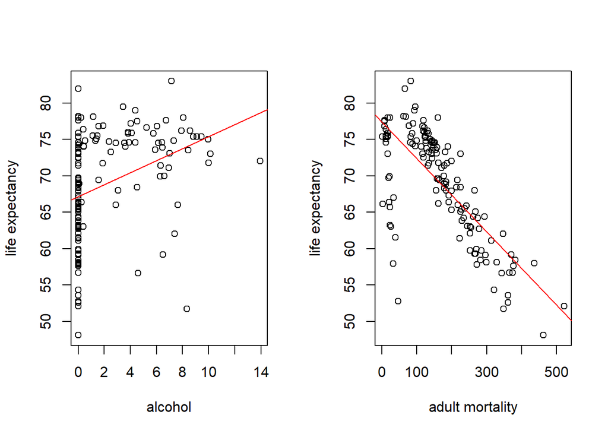

From the graphs we see clearly what emerged from the models: - the first graph is strongly influenced by the values associated with Arab countries where alcohol consumption is almost null - the second graph shows the inverse relationship between life expectancy and adult mortality in developing countries

We empirically verify that the beta coefficient is significant for the model Life expectancy ~ Adult mortality H0: b=0 vs H1: b!=0

```r
a<-0.05 #significance level
b2_bis<-coef(mod2_bis_bis)[[2]] #extraction of second coefficient
se_b2_bis<-sqrt(vcov(mod2_bis_bis)[2,2]) #extraction the square root of the variance of beta from the "variance-covariance matrix"
df_bis<- df.residual(mod2_bis_bis) #degrees of freedom
t_bis<-b2_bis/se_b2_bis #value of statistic test
tc_bis<-qt(1-a/2, df_bis) #critic value
t_bis;tc_bis
```

```
## [1] -13.17917
```

```
## [1] 1.976692
```

Since the absolute value of the statistic test is greater than the critical value, we reject the null hypothesis at a significance level of 5%.

At this point in the analysis, after observing that life expectancy is significantly explained by the mortality rate for both developed and developing countries, we decide to investigate if there is a difference between the years of study (variable ‘Schooling’) for the two groups. With this purpose, we have taken all the available data (38) for the developed countries, while for those developing we have sampled (38) as many as the observations of developed.

```r
#we observe the statistics of synthesis of the two datasets and verify that the variable schooling is indeed quantitative
summary(developed_tot)
```

```
##    Country               Year         Status          Life.expectancy
##  Length:38          Min.   :2014   Length:38          Min.   :73.40
##  Class :character   1st Qu.:2014   Class :character   1st Qu.:78.72
##  Mode  :character   Median :2014   Mode  :character   Median :81.85
##                     Mean   :2014                      Mean   :81.50
##                     3rd Qu.:2014                      3rd Qu.:82.97
##                     Max.   :2014                      Max.   :89.00
##  Adult.Mortality  infant.deaths       Alcohol       percentage.expenditure
##  Min.   :  6.00   Min.   : 0.000   Min.   : 0.010   Min.   :    0.0
##  1st Qu.: 56.25   1st Qu.: 0.000   1st Qu.: 3.480   1st Qu.:  155.1
##  Median : 66.50   Median : 0.000   Median : 8.945   Median : 1091.2
##  Mean   : 73.79   Mean   : 1.211   Mean   : 7.528   Mean   : 3382.9
##  3rd Qu.: 78.75   3rd Qu.: 1.000   3rd Qu.:10.740   3rd Qu.: 5831.3
##  Max.   :169.00   Max.   :23.000   Max.   :15.190   Max.   :19479.9
##   Hepatitis.B       Measles           BMI        under.five.deaths
##  Min.   : 9.00   Min.   :  0.0   Min.   : 6.60   Min.   : 0.000
##  1st Qu.:80.94   1st Qu.:  0.0   1st Qu.:58.40   1st Qu.: 0.000
##  Median :93.00   Median : 24.5   Median :61.80   Median : 0.000
##  Mean   :87.17   Mean   :105.3   Mean   :53.71   Mean   : 1.421
##  3rd Qu.:96.00   3rd Qu.:138.2   3rd Qu.:64.97   3rd Qu.: 1.000
##  Max.   :99.00   Max.   :667.0   Max.   :69.20   Max.   :27.000
##      Polio       Total.expenditure   Diphtheria       HIV.AIDS
##  Min.   : 9.00   Min.   : 1.230    Min.   : 9.00   Min.   :0.1
##  1st Qu.:93.25   1st Qu.: 6.423    1st Qu.:94.00   1st Qu.:0.1
##  Median :95.50   Median : 8.470    Median :96.00   Median :0.1
##  Mean   :93.37   Mean   : 7.942    Mean   :93.42   Mean   :0.1
##  3rd Qu.:98.00   3rd Qu.: 9.635    3rd Qu.:98.00   3rd Qu.:0.1
##  Max.   :99.00   Max.   :17.140    Max.   :99.00   Max.   :0.1
##       GDP              Population       thinness..1.19.years thinness.5.9.years
##  Min.   :    12.28   Min.   :   14162   Min.   :0.300        Min.   :0.200
##  1st Qu.:  4538.10   1st Qu.:  459603   1st Qu.:0.800        1st Qu.:0.600
##  Median : 13792.72   Median : 3372051   Median :1.000        Median :0.950
##  Mean   : 24819.24   Mean   : 6893439   Mean   :1.213        Mean   :1.168
##  3rd Qu.: 46318.36   3rd Qu.: 8453344   3rd Qu.:1.775        3rd Qu.:1.675
##  Max.   :119172.74   Max.   :66331957   Max.   :2.600        Max.   :2.800
##  Income.composition.of.resources   Schooling
##  Min.   :  0.82                  Min.   :11.99
##  1st Qu.:141.72                  1st Qu.:15.15
##  Median :841.00                  Median :16.10
##  Mean   :623.95                  Mean   :16.14
##  3rd Qu.:898.00                  3rd Qu.:17.15
##  Max.   :945.00                  Max.   :20.40
```

```r
summary(developing_tot)
```

```
##    Country               Year         Status          Life.expectancy
##  Length:145         Min.   :2014   Length:145         Min.   :48.10
##  Class :character   1st Qu.:2014   Class :character   1st Qu.:63.80
##  Mode  :character   Median :2014   Mode  :character   Median :70.00
##                     Mean   :2014                      Mean   :68.92
##                     3rd Qu.:2014                      3rd Qu.:74.80
##                     Max.   :2014                      Max.   :83.00
##  Adult.Mortality infant.deaths       Alcohol       percentage.expenditure
##  Min.   :  1.0   Min.   :  0.00   Min.   : 0.010   Min.   :   0.000
##  1st Qu.: 93.0   1st Qu.:  1.00   1st Qu.: 0.010   1st Qu.:   8.386
##  Median :155.0   Median :  6.00   Median : 0.010   Median :  80.927
##  Mean   :168.3   Mean   : 30.68   Mean   : 2.165   Mean   : 377.925
##  3rd Qu.:237.0   3rd Qu.: 26.00   3rd Qu.: 4.030   3rd Qu.: 463.640
##  Max.   :522.0   Max.   :957.00   Max.   :13.940   Max.   :5063.513
##   Hepatitis.B      Measles           BMI        under.five.deaths
##  Min.   : 2.0   Min.   :    0   Min.   : 2.00   Min.   :   0.00
##  1st Qu.:78.0   1st Qu.:    0   1st Qu.:22.70   1st Qu.:   1.00
##  Median :92.0   Median :   13   Median :35.80   Median :   7.00
##  Mean   :81.9   Mean   : 2284   Mean   :37.67   Mean   :  41.14
##  3rd Qu.:97.0   3rd Qu.:  344   3rd Qu.:55.30   3rd Qu.:  36.00
##  Max.   :99.0   Max.   :79563   Max.   :77.10   Max.   :1200.00
##      Polio       Total.expenditure   Diphtheria       HIV.AIDS
##  Min.   : 8.00   Min.   : 1.210    Min.   : 2.00   Min.   :0.1000
##  1st Qu.:77.00   1st Qu.: 4.260    1st Qu.:77.00   1st Qu.:0.1000
##  Median :92.00   Median : 5.640    Median :92.00   Median :0.1000
##  Mean   :82.46   Mean   : 5.741    Mean   :81.63   Mean   :0.8345
##  3rd Qu.:97.00   3rd Qu.: 7.200    3rd Qu.:97.00   3rd Qu.:0.6000
##  Max.   :99.00   Max.   :13.730    Max.   :99.00   Max.   :9.4000
##       GDP             Population        thinness..1.19.years thinness.5.9.years
##  Min.   :   25.45   Min.   :4.100e+01   Min.   : 0.100       Min.   : 0.100
##  1st Qu.:  642.63   1st Qu.:5.479e+05   1st Qu.: 2.200       1st Qu.: 2.400
##  Median : 3491.60   Median :4.515e+06   Median : 4.900       Median : 5.200
##  Mean   : 5646.97   Mean   :2.243e+07   Mean   : 5.407       Mean   : 5.598
##  3rd Qu.: 7483.16   3rd Qu.:1.275e+07   3rd Qu.: 7.100       3rd Qu.: 7.300
##  Max.   :86852.71   Max.   :1.294e+09   Max.   :26.800       Max.   :27.400
##  Income.composition.of.resources   Schooling
##  Min.   :  0.39                  Min.   : 4.90
##  1st Qu.:487.00                  1st Qu.:10.60
##  Median :614.00                  Median :12.40
##  Mean   :568.98                  Mean   :11.97
##  3rd Qu.:739.00                  3rd Qu.:13.50
##  Max.   :863.00                  Max.   :17.30
```

After making sure that the schooling variable is quantitative, we defined the two variables (schooling_developed and schooling_developing) extracting them from the two respective datasets and we sampled 38 values (with reimmission) from the observations of developing countries.

```r
#we want to see if there is difference between the average school years between developed and undeveloped countries

schooling_developed<-developed_tot$Schooling
schooling_developing<-developing_tot$Schooling

#extract 38 values from the developing subset to create a dataframe with the same number of developed and developing observation
set.seed(123) #we fix the 'seeds' to be able to extract pseudo random numbers and guarantee the replicability of the extraction
schooling_developing_sample<-sample(schooling_developing, 38, replace=TRUE )
schooling_developing_sample
```

```
##  [1] 12.80000 13.50000  4.90000 13.20000 12.80000  4.90000 12.40000 11.60000
##  [9] 11.60000  5.30000 11.99279 13.40000 10.80000 10.90000 12.70000 11.99279
## [17] 12.70000 14.70000 13.20000 11.99279 13.00000 10.70000  9.00000 13.60000
## [25] 11.10000 12.70000 11.99279 13.40000 10.60000 10.70000 15.20000 10.70000
## [33] 11.10000 12.80000 10.80000 10.70000 12.80000 14.20000
```

Creation of the vector of the observations and join them in a single vector, then coding it as double

```r
#vector with the 38 values for developed countires
scho_devlopd<-c('20.40000', '15.90000', '16.30000', '14.80000', '15.90000', '15.10000', '14.00000', '11.99279', '19.20000', '16.50000',
                '17.00000', '16.20000', '17.00000', '17.20000', '15.80000', '19.00000', '18.60000', '16.00000', '16.30000', '15.30000',
                 '16.00000', '16.50000', '13.90000', '14.30000', '18.10000', '19.20000', '17.70000', '16.40000', '16.80000', '14.70000',
                '15.40000', '15.10000', '17.60000', '17.60000', '15.80000', '15.90000', '11.99279','11.99279')

#vector with the 38 values for developing countires
scho_devloping<-c('12.80000', '13.50000',  '4.90000', '13.20000', '12.80000',  '4.90000', '12.40000', '11.60000', '11.60000',  '5.30000',
                 '11.99279', '13.40000', '10.80000', '10.90000', '12.70000', '11.99279', '12.70000', '14.70000', '13.20000', '11.99279',
                 '13.00000', '10.70000',  '9.00000', '13.60000', '11.10000', '12.70000', '11.99279', '13.40000', '10.60000', '10.70000',
                 '15.20000', '10.70000', '11.10000', '12.80000', '10.80000', '10.70000', '12.80000', '14.20000')
#vettoore con i 38 valori di developed  e i 38 di developing
scho<-c('20.40000', '15.90000', '16.30000', '14.80000', '15.90000', '15.10000', '14.00000', '11.99279', '19.20000', '16.50000',
        '17.00000', '16.20000', '17.00000', '17.20000', '15.80000', '19.00000', '18.60000', '16.00000', '16.30000', '15.30000',
        '16.00000', '16.50000', '13.90000', '14.30000', '18.10000', '19.20000', '17.70000', '16.40000', '16.80000', '14.70000',
        '15.40000', '15.10000', '17.60000', '17.60000', '15.80000', '15.90000', '11.99279','11.99279','12.80000', '13.50000',  '4.90000', '13.20000', '12.80000',  '4.90000', '12.40000', '11.60000', '11.60000',  '5.30000',
'11.99279', '13.40000', '10.80000', '10.90000', '12.70000', '11.99279', '12.70000', '14.70000', '13.20000', '11.99279',
'13.00000', '10.70000',  '9.00000', '13.60000', '11.10000', '12.70000', '11.99279', '13.40000', '10.60000', '10.70000',
'15.20000', '10.70000', '11.10000', '12.80000', '10.80000', '10.70000', '12.80000', '14.20000')
scho<-as.double(scho)
```

Creating the dichotomous ‘status’ variable to split observations in groups

```r
status<-c(rep('developed', 38), rep('developing', 38))
```

Creaion of the dataframe useful for the test, and then the observation of the structure (*str()*) and statistics of synthesis (*summary()*)

```r
data_schooling<-data.frame(scho, status)

str(data_schooling)
```

```
## 'data.frame':    76 obs. of  2 variables:
##  $ scho  : num  20.4 15.9 16.3 14.8 15.9 ...
##  $ status: chr  "developed" "developed" "developed" "developed" ...
```

```r
summary(data_schooling)
```

```
##       scho          status
##  Min.   : 4.90   Length:76
##  1st Qu.:11.99   Class :character
##  Median :13.75   Mode  :character
##  Mean   :13.89
##  3rd Qu.:16.05
##  Max.   :20.40
```

After putting together all the ‘ingredients’, we can dedicate to the test in the two-tailed form: H0:averages of the two groups are equal (mean1-mean2=0) H1:Averages of the two groups differ (mean1-mean2 !=0)

```r
t.test(scho ~ status, data = data_schooling,
       alternative = 'two.sided',
       conf.level = .95)
```

```
##
##  Welch Two Sample t-test
##
## data:  scho by status
## t = 9.1354, df = 71.296, p-value = 1.274e-13
## alternative hypothesis: true difference in means between group developed and group developing is not equal to 0
## 95 percent confidence interval:
##  3.518023 5.482356
## sample estimates:
##  mean in group developed mean in group developing
##                 16.14417                 11.64398
```

By the fact that -p value is very small and certainly less than 5% significance (alpha=0.05) - the value of t observed does not belong to the confidence interval calculated with a confidence level of 95% [3.518023, 5.482356]

We reject the null hypothesis, at a level of significance of 5%, that there is no difference between the averages of the two groups. In fact, there is a difference between the two sets, developing and developed: indeveloped countries, schooling is compulsory until advanced age and the drop-out rate is considerably reduced than in developing countries. In these countries, the proportion of children or young people who work and leave school early is still very high.

We replicate the test to a ‘one’ tail, so we are imposing the following hypotheses: H0:mean1-mean2<0 H1:mean1-mean2 >=0

```r
t.test(scho ~ status, data = data_schooling,
       alternative = 'greater',
       conf.level = .95)
```

```
##
##  Welch Two Sample t-test
##
## data:  scho by status
## t = 9.1354, df = 71.296, p-value = 6.368e-14
## alternative hypothesis: true difference in means between group developed and group developing is greater than 0
## 95 percent confidence interval:
##  3.67925     Inf
## sample estimates:
##  mean in group developed mean in group developing
##                 16.14417                 11.64398
```

Since the observed p value or empirical value (p-value = 6.368e-14) is less than alpha, significance level, we reject the null hypothesis.

So we further confirm that in developed countries on average, more time is devoted to education than in developing countries.

**MULTIPLE LINEAR REGRESSION ANALYSIS**

Running a regression model with a lot of variables (including the irrelevant ones) will lead to an unnecessary complex model. A simple way of running a regression model with many variables (consistent or not consistent) is the *Stepwise regression* method. In this way we select step by step the most important variables getting an easily interpretative model. We concentrate the attention on the *backward stepwise selection* method which begins with a model that contains all variables we want consider, and then removes the least significant variables one after the other. The final model is reached when a specific rule makes the running stops. The target variable of our regression model is $Y$, a linear function of the variables $x_{ij}$. The following expression shows the relationship between each observation of a specific variable of the dataset and the predicted value:

$$\\ y_i =\gamma_0 + \gamma_1x_{1i} +
\gamma_2x_{2i}+ ...\gamma_nx_{ni}+\epsilon_i \\$$

where $\epsilon_i$ are the residuals associated to each observation. We decide that *Life.expectancy* is the target variable that will be explained through 12 specific variables of our dataset, namely:

- `Status (a dummy variable)`
- `Adult.Mortality`
- `Alcohol`
- `Hepatitis.B`
- `Measles`
- `BMI`
- `under.five.deaths`
- `Polio`
- `Total.expenditure`
- `HIV.AIDS`
- `GDP`
- `Income.composition.of.resources`

To avoid the multicollinearity problem we have decided a list of few varibles. As a matter of fact, this effect would make $\gamma$coefficients numerically unstable. Some variables are not taken in consideration because they are too little correlated with the target variable *Life.expectancy* (for example *Population* or *Schooling* variables). Since it is a qualitative variable, the variable *Status* is changed into a binary variable which can assume only 2 values: 0 (*Developed*) and 1 (*Developing*).

```r
developed_developing<-read.csv('C:\\Users\\HP\\Desktop\\STATISTICA\\developed&developing.csv', header=TRUE, sep=',')
head(developed_developing)
```

```
##     Country Year    Status Life.expectancy Adult.Mortality infant.deaths
## 1 Australia 2014 Developed            82.7               6             1
## 2   Austria 2014 Developed            81.4              66             0
## 3   Belgium 2014 Developed            89.0              76             0
## 4  Bulgaria 2014 Developed            74.3             138             1
## 5    Canada 2014 Developed            82.0              65             2
## 6   Croatia 2014 Developed            77.8              97             0
##   Alcohol percentage.expenditure Hepatitis.B Measles  BMI under.five.deaths
## 1    9.71             10769.3630          91     340 66.1                 1
## 2   12.32              8350.1935          98     117 57.1                 0
## 3   12.60              7163.3489          98      70 63.4                 1
## 4   12.03               153.1400          95       0 65.1                 1
## 5    8.10               102.1902          55     418 66.4                 2
## 6   12.14              1884.0988          95       0 63.1                 0
##   Polio Total.expenditure Diphtheria HIV.AIDS        GDP Population
```

[output cut: 20 more lines]

```r
as.factor(developed_developing$Status)
```

```
##   [1] Developed  Developed  Developed  Developed  Developed  Developed
##   [7] Developed  Developed  Developed  Developed  Developed  Developed
##  [13] Developed  Developed  Developed  Developed  Developed  Developed
##  [19] Developed  Developed  Developed  Developed  Developed  Developed
##  [25] Developed  Developed  Developed  Developed  Developed  Developed
##  [31] Developed  Developed  Developed  Developed  Developed  Developed
##  [37] Developed  Developed  Developing Developing Developing Developing
##  [43] Developing Developing Developing Developing Developing Developing
##  [49] Developing Developing Developing Developing Developing Developing
##  [55] Developing Developing Developing Developing Developing Developing
##  [61] Developing Developing Developing Developing Developing Developing
##  [67] Developing Developing Developing Developing Developing Developing
##  [73] Developing Developing Developing Developing Developing Developing
##  [79] Developing Developing Developing Developing Developing Developing
##  [85] Developing Developing Developing Developing Developing Developing
##  [91] Developing Developing Developing Developing Developing Developing
##  [97] Developing Developing Developing Developing Developing Developing
## [103] Developing Developing Developing Developing Developing Developing
## [109] Developing Developing Developing Developing Developing Developing
## [115] Developing Developing Developing Developing Developing Developing
## [121] Developing Developing Developing Developing Developing Developing
## [127] Developing Developing Developing Developing Developing Developing
## [133] Developing Developing Developing Developing Developing Developing
## [139] Developing Developing Developing Developing Developing Developing
## [145] Developing Developing Developing Developing Developing Developing
## [151] Developing Developing Developing Developing Developing Developing
## [157] Developing Developing Developing Developing Developing Developing
## [163] Developing Developing Developing Developing Developing Developing
## [169] Developing Developing Developing Developing
## Levels: Developed Developing
```

```r
developed_developing[developed_developing$Status=="Developed",]$Status=0
developed_developing[developed_developing$Status=="Developing",]$Status=1
as.numeric(developed_developing$Status)
```

```
##   [1] 0 0 0 0 0 0 0 0 0 0 0 0 0 0 0 0 0 0 0 0 0 0 0 0 0 0 0 0 0 0 0 0 0 0 0 0 0
##  [38] 0 1 1 1 1 1 1 1 1 1 1 1 1 1 1 1 1 1 1 1 1 1 1 1 1 1 1 1 1 1 1 1 1 1 1 1 1
##  [75] 1 1 1 1 1 1 1 1 1 1 1 1 1 1 1 1 1 1 1 1 1 1 1 1 1 1 1 1 1 1 1 1 1 1 1 1 1
## [112] 1 1 1 1 1 1 1 1 1 1 1 1 1 1 1 1 1 1 1 1 1 1 1 1 1 1 1 1 1 1 1 1 1 1 1 1 1
## [149] 1 1 1 1 1 1 1 1 1 1 1 1 1 1 1 1 1 1 1 1 1 1 1 1
```

We split developed_developing dataset in two parts: *train* and *test*. Training consists of 80% of data and testing is made by the other 20%. The latter is to verify the reliability of our model, namely how good we are able to learn the data behavior by means of the model.

```r
rows<-nrow(developed_developing)
index<-0.80*rows
train <- developed_developing[1:index, ]
test <- developed_developing[-(1:index), ]
```

We start with the first model:

```r
model_1<-lm(Life.expectancy~Status+ Adult.Mortality + Alcohol + Hepatitis.B + Measles + BMI+ under.five.deaths + Polio +Total.expenditure+HIV.AIDS + GDP+Income.composition.of.resources,train)
summary(model_1)
```

```
##
## Call:
## lm(formula = Life.expectancy ~ Status + Adult.Mortality + Alcohol +
##     Hepatitis.B + Measles + BMI + under.five.deaths + Polio +
##     Total.expenditure + HIV.AIDS + GDP + Income.composition.of.resources,
##     data = train)
##
## Residuals:
##      Min       1Q   Median       3Q      Max
## -16.2862  -2.7078   0.2384   2.3748   9.0378
##
## Coefficients:
##                                   Estimate Std. Error t value Pr(>|t|)
## (Intercept)                      7.314e+01  2.772e+00  26.391  < 2e-16 ***
## Status1                         -5.662e+00  1.143e+00  -4.953 2.33e-06 ***
## Adult.Mortality                 -2.675e-02  5.364e-03  -4.987 2.02e-06 ***
## Alcohol                          1.452e-01  1.146e-01   1.268 0.207342
## Hepatitis.B                      4.316e-02  2.170e-02   1.989 0.048881 *
## Measles                          6.807e-05  6.739e-05   1.010 0.314377
## BMI                              4.258e-02  2.115e-02   2.013 0.046237 *
## under.five.deaths               -6.801e-03  4.586e-03  -1.483 0.140651
## Polio                           -9.396e-03  2.350e-02  -0.400 0.690026
## Total.expenditure                2.866e-01  1.439e-01   1.992 0.048594 *
## HIV.AIDS                        -1.550e+00  3.975e-01  -3.898 0.000158 ***
## GDP                              4.239e-05  2.487e-05   1.705 0.090784 .
## Income.composition.of.resources  1.437e-03  1.383e-03   1.039 0.300920
## ---
## Signif. codes:  0 '***' 0.001 '**' 0.01 '*' 0.05 '.' 0.1 ' ' 1
##
## Residual standard error: 4.257 on 124 degrees of freedom
## Multiple R-squared:  0.7903, Adjusted R-squared:   0.77
## F-statistic: 38.95 on 12 and 124 DF,  p-value: < 2.2e-16
```

```r
model_2<-update(model_1,.~.-Polio)
summary(model_2)
```

```
##
## Call:
## lm(formula = Life.expectancy ~ Status + Adult.Mortality + Alcohol +
##     Hepatitis.B + Measles + BMI + under.five.deaths + Total.expenditure +
##     HIV.AIDS + GDP + Income.composition.of.resources, data = train)
##
## Residuals:
##      Min       1Q   Median       3Q      Max
## -16.2948  -2.7603   0.2404   2.3891   9.0640
##
## Coefficients:
##                                   Estimate Std. Error t value Pr(>|t|)
## (Intercept)                      7.271e+01  2.542e+00  28.599  < 2e-16 ***
## Status1                         -5.581e+00  1.121e+00  -4.978 2.08e-06 ***
## Adult.Mortality                 -2.662e-02  5.336e-03  -4.989 1.98e-06 ***
## Alcohol                          1.485e-01  1.139e-01   1.304 0.194665
## Hepatitis.B                      3.796e-02  1.731e-02   2.193 0.030153 *
## Measles                          6.646e-05  6.704e-05   0.991 0.323420
## BMI                              4.237e-02  2.107e-02   2.011 0.046479 *
## under.five.deaths               -6.747e-03  4.569e-03  -1.477 0.142290
## Total.expenditure                2.841e-01  1.433e-01   1.982 0.049616 *
## HIV.AIDS                        -1.518e+00  3.885e-01  -3.908 0.000151 ***
## GDP                              4.331e-05  2.468e-05   1.755 0.081710 .
## Income.composition.of.resources  1.405e-03  1.376e-03   1.021 0.309133
## ---
## Signif. codes:  0 '***' 0.001 '**' 0.01 '*' 0.05 '.' 0.1 ' ' 1
##
## Residual standard error: 4.242 on 125 degrees of freedom
## Multiple R-squared:  0.7901, Adjusted R-squared:  0.7716
## F-statistic: 42.77 on 11 and 125 DF,  p-value: < 2.2e-16
```

We notice that almost nothing changes but the $R^{2}_{adjusted}$ which increases slightly.  
Now we remove *Measles*:

```r
model_3<-update(model_2,.~.-Measles)
summary(model_3)
```

```
##
## Call:
## lm(formula = Life.expectancy ~ Status + Adult.Mortality + Alcohol +
##     Hepatitis.B + BMI + under.five.deaths + Total.expenditure +
##     HIV.AIDS + GDP + Income.composition.of.resources, data = train)
##
## Residuals:
##      Min       1Q   Median       3Q      Max
## -16.5189  -2.7420   0.2034   2.5030   8.9698
##
## Coefficients:
##                                   Estimate Std. Error t value Pr(>|t|)
## (Intercept)                      7.267e+01  2.542e+00  28.588  < 2e-16 ***
## Status1                         -5.499e+00  1.118e+00  -4.918 2.67e-06 ***
## Adult.Mortality                 -2.684e-02  5.331e-03  -5.035 1.61e-06 ***
## Alcohol                          1.624e-01  1.130e-01   1.437 0.153218
## Hepatitis.B                      3.757e-02  1.730e-02   2.171 0.031772 *
## BMI                              4.151e-02  2.105e-02   1.972 0.050808 .
## under.five.deaths               -3.274e-03  2.934e-03  -1.116 0.266488
## Total.expenditure                2.824e-01  1.433e-01   1.971 0.050875 .
## HIV.AIDS                        -1.553e+00  3.869e-01  -4.015 0.000101 ***
## GDP                              4.302e-05  2.467e-05   1.744 0.083685 .
## Income.composition.of.resources  1.500e-03  1.373e-03   1.093 0.276449
## ---
## Signif. codes:  0 '***' 0.001 '**' 0.01 '*' 0.05 '.' 0.1 ' ' 1
##
## Residual standard error: 4.242 on 126 degrees of freedom
## Multiple R-squared:  0.7884, Adjusted R-squared:  0.7716
## F-statistic: 46.95 on 10 and 126 DF,  p-value: < 2.2e-16
```

```r
model_4<-update(model_3,.~.-Income.composition.of.resources)
summary(model_4)
```

```
##
## Call:
## lm(formula = Life.expectancy ~ Status + Adult.Mortality + Alcohol +
##     Hepatitis.B + BMI + under.five.deaths + Total.expenditure +
##     HIV.AIDS + GDP, data = train)
##
## Residuals:
##      Min       1Q   Median       3Q      Max
## -16.6482  -2.4841   0.3408   2.6635   9.2250
##
## Coefficients:
##                     Estimate Std. Error t value Pr(>|t|)
## (Intercept)        7.355e+01  2.412e+00  30.496  < 2e-16 ***
## Status1           -5.443e+00  1.118e+00  -4.870 3.25e-06 ***
## Adult.Mortality   -2.773e-02  5.272e-03  -5.259 5.95e-07 ***
## Alcohol            1.668e-01  1.130e-01   1.475 0.142651
## Hepatitis.B        3.935e-02  1.724e-02   2.282 0.024145 *
## BMI                3.935e-02  2.097e-02   1.876 0.062932 .
## under.five.deaths -3.329e-03  2.935e-03  -1.134 0.258838
## Total.expenditure  2.802e-01  1.434e-01   1.954 0.052844 .
## HIV.AIDS          -1.553e+00  3.872e-01  -4.011 0.000103 ***
## GDP                4.563e-05  2.458e-05   1.857 0.065654 .
## ---
## Signif. codes:  0 '***' 0.001 '**' 0.01 '*' 0.05 '.' 0.1 ' ' 1
##
## Residual standard error: 4.245 on 127 degrees of freedom
## Multiple R-squared:  0.7864, Adjusted R-squared:  0.7713
## F-statistic: 51.95 on 9 and 127 DF,  p-value: < 2.2e-16
```

Again, almost nothing changes but a little variation of the $R^{2}$ and $R^{2}_{adjusted}$.  
We remove $under.five.deaths$ variable

```r
model_5<-update(model_4,.~.-under.five.deaths)
summary(model_5)
```

```
##
## Call:
## lm(formula = Life.expectancy ~ Status + Adult.Mortality + Alcohol +
##     Hepatitis.B + BMI + Total.expenditure + HIV.AIDS + GDP, data = train)
##
## Residuals:
##     Min      1Q  Median      3Q     Max
## -16.815  -2.453   0.452   2.503   9.397
##
## Coefficients:
##                     Estimate Std. Error t value Pr(>|t|)
## (Intercept)        7.313e+01  2.385e+00  30.662  < 2e-16 ***
## Status1           -5.481e+00  1.118e+00  -4.901 2.83e-06 ***
## Adult.Mortality   -2.833e-02  5.251e-03  -5.396 3.19e-07 ***
## Alcohol            1.608e-01  1.130e-01   1.422  0.15736
## Hepatitis.B        4.150e-02  1.715e-02   2.419  0.01696 *
## BMI                4.292e-02  2.076e-02   2.068  0.04069 *
## Total.expenditure  2.928e-01  1.431e-01   2.047  0.04273 *
## HIV.AIDS          -1.527e+00  3.869e-01  -3.947  0.00013 ***
## GDP                4.681e-05  2.458e-05   1.904  0.05911 .
## ---
## Signif. codes:  0 '***' 0.001 '**' 0.01 '*' 0.05 '.' 0.1 ' ' 1
##
## Residual standard error: 4.25 on 128 degrees of freedom
## Multiple R-squared:  0.7842, Adjusted R-squared:  0.7708
## F-statistic: 58.16 on 8 and 128 DF,  p-value: < 2.2e-16
```

```r
model_6<-update(model_5,.~.-Alcohol)
summary(model_6)
```

```
##
## Call:
## lm(formula = Life.expectancy ~ Status + Adult.Mortality + Hepatitis.B +
##     BMI + Total.expenditure + HIV.AIDS + GDP, data = train)
##
## Residuals:
##      Min       1Q   Median       3Q      Max
## -16.9576  -2.6063   0.2042   2.5556  10.1994
##
## Coefficients:
##                     Estimate Std. Error t value Pr(>|t|)
## (Intercept)        7.336e+01  2.389e+00  30.713  < 2e-16 ***
## Status1           -6.032e+00  1.053e+00  -5.726 6.85e-08 ***
## Adult.Mortality   -2.803e-02  5.268e-03  -5.321 4.43e-07 ***
## Hepatitis.B        4.230e-02  1.721e-02   2.457   0.0153 *
## BMI                5.057e-02  2.013e-02   2.512   0.0132 *
## Total.expenditure  3.336e-01  1.407e-01   2.370   0.0193 *
## HIV.AIDS          -1.579e+00  3.867e-01  -4.085 7.71e-05 ***
## GDP                5.300e-05  2.429e-05   2.182   0.0309 *
## ---
## Signif. codes:  0 '***' 0.001 '**' 0.01 '*' 0.05 '.' 0.1 ' ' 1
##
## Residual standard error: 4.267 on 129 degrees of freedom
## Multiple R-squared:  0.7808, Adjusted R-squared:  0.7689
## F-statistic: 65.66 on 7 and 129 DF,  p-value: < 2.2e-16
```

```r
library("olsrr")
backward_model.p<-ols_step_backward_p(model_1, prem=0.1, details=TRUE)
```

```
## Backward Elimination Method
## ---------------------------
##
## Candidate Terms:
##
## 1 . Status
## 2 . Adult.Mortality
## 3 . Alcohol
## 4 . Hepatitis.B
## 5 . Measles
## 6 . BMI
## 7 . under.five.deaths
## 8 . Polio
## 9 . Total.expenditure
## 10 . HIV.AIDS
## 11 . GDP
## 12 . Income.composition.of.resources
##
## We are eliminating variables based on p value...
##
## - Polio
##
## Backward Elimination: Step 1
##
##  Variable Polio Removed
##
##                         Model Summary
## --------------------------------------------------------------
## R                       0.889       RMSE                4.242
## R-Squared               0.790       Coef. Var           5.867
## Adj. R-Squared          0.772       MSE                17.996
## Pred R-Squared          0.733       MAE                 3.129
## --------------------------------------------------------------
##  RMSE: Root Mean Square Error
##  MSE: Mean Square Error
##  MAE: Mean Absolute Error
##
##                                 ANOVA
## ----------------------------------------------------------------------
##                  Sum of
```

[output cut: 235 more lines]

```
## ----------------------------------------------------------------------
##
##                                      Parameter Estimates
## ----------------------------------------------------------------------------------------------
##             model      Beta    Std. Error    Std. Beta      t        Sig      lower     upper
## ----------------------------------------------------------------------------------------------
##       (Intercept)    73.361         2.389                 30.713    0.000    68.635    78.087
##           Status1    -6.032         1.053       -0.305    -5.726    0.000    -8.116    -3.948
##   Adult.Mortality    -0.028         0.005       -0.329    -5.321    0.000    -0.038    -0.018
##       Hepatitis.B     0.042         0.017        0.108     2.457    0.015     0.008     0.076
##               BMI     0.051         0.020        0.120     2.512    0.013     0.011     0.090
## Total.expenditure     0.334         0.141        0.107     2.370    0.019     0.055     0.612
##          HIV.AIDS    -1.579         0.387       -0.230    -4.085    0.000    -2.345    -0.814
##               GDP     0.000         0.000        0.107     2.182    0.031     0.000     0.000
## ----------------------------------------------------------------------------------------------
```

```r
backward_model.aic<-ols_step_backward_aic(model_1, details=TRUE)
```

```
## Backward Elimination Method
## ---------------------------
##
## Candidate Terms:
##
## 1 . Status
## 2 . Adult.Mortality
## 3 . Alcohol
## 4 . Hepatitis.B
## 5 . Measles
## 6 . BMI
## 7 . under.five.deaths
## 8 . Polio
## 9 . Total.expenditure
## 10 . HIV.AIDS
## 11 . GDP
## 12 . Income.composition.of.resources
##
##  Step 0: AIC = 800.007
##  Life.expectancy ~ Status + Adult.Mortality + Alcohol + Hepatitis.B + Measles + BMI + under.five.deaths + Polio + Total.expenditure + HIV.AIDS + GDP + Income.composition.of.resources
##
## -------------------------------------------------------------------------------
## Variable             DF      AIC      Sum Sq       RSS       R-Sq     Adj. R-Sq
## -------------------------------------------------------------------------------
## Polio                1     798.183      2.895    2249.537    0.790        0.772
## Measles              1     799.130     18.489    2265.130    0.789        0.770
## Income.composition.of.resources    1     799.194     19.551    2266.193    0.789        0.770
## Alcohol              1     799.771     29.109    2275.750    0.788        0.769
## under.five.deaths    1     800.415     39.839    2286.480    0.787        0.768
## GDP                  1     801.180     52.642    2299.283    0.785        0.767
## Hepatitis.B          1     802.310     71.691    2318.333    0.784        0.765
## Total.expenditure    1     802.321     71.877    2318.518    0.784        0.765
## BMI                  1     802.414     73.447    2320.088    0.783        0.764
## HIV.AIDS             1     813.843    275.301    2521.943    0.765        0.744
## Status               1     822.741    444.523    2691.165    0.749        0.727
## Adult.Mortality      1     823.053    450.662    2697.303    0.748        0.726
## -------------------------------------------------------------------------------
##
##
## Variables Removed:
```

[output cut: 117 more lines]

```
##
##                                      Parameter Estimates
## ----------------------------------------------------------------------------------------------
##             model      Beta    Std. Error    Std. Beta      t        Sig      lower     upper
## ----------------------------------------------------------------------------------------------
##       (Intercept)    73.125         2.385                 30.662    0.000    68.406    77.844
##           Status1    -5.481         1.118       -0.277    -4.901    0.000    -7.694    -3.268
##   Adult.Mortality    -0.028         0.005       -0.332    -5.396    0.000    -0.039    -0.018
##           Alcohol     0.161         0.113        0.079     1.422    0.157    -0.063     0.384
##       Hepatitis.B     0.042         0.017        0.106     2.419    0.017     0.008     0.075
##               BMI     0.043         0.021        0.101     2.068    0.041     0.002     0.084
## Total.expenditure     0.293         0.143        0.094     2.047    0.043     0.010     0.576
##          HIV.AIDS    -1.527         0.387       -0.222    -3.947    0.000    -2.293    -0.761
##               GDP     0.000         0.000        0.094     1.904    0.059     0.000     0.000
## ----------------------------------------------------------------------------------------------
```

As we expected, the *backward stepwise* selection based on p-value gives the same result of *model_6*, while the backward stepwise selection based on the AIC gives the same result of *model_5* which includes $Alcohol$ variable (non-loss of information about variables.) Scatterplot of Actual vs Predicted values for the target variable shows how much our results (the points) are close to the regressed line.

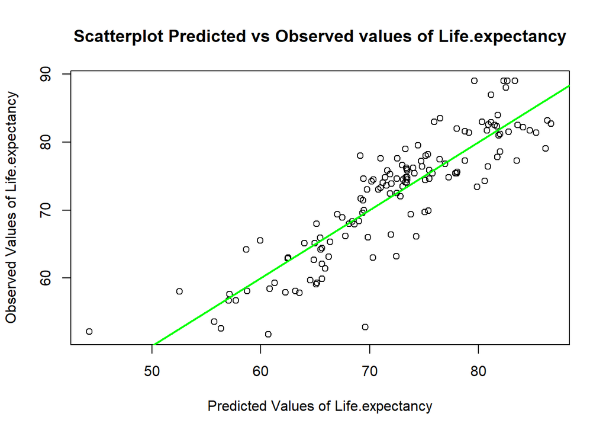

```r
options(repr.plot.width=10,repr.plot.height=10,repr.plot.res=150)

plot(predict(model_5), train$Life.expectancy, xlab = "Predicted Values of Life.expectancy", ylab = "Observed Values of Life.expectancy", main="Scatterplot Predicted vs Observed values of Life.expectancy")
abline(a = 0, b = 1, col = "green", lwd = 2)
```

We use the coefficient of determination $R^{2}$ (the percentage of the variation of the target variable explained by the model) to evaluate how good the multiple regression fit is. For this reason we decide to compare the variation of $R^{2}$ and $R^{2}_{adjusted}$ when we removed the non-significant influencing variables from the model:

```r
#memorizzo r adjusted
M1=summary(model_1)$adj.r.squared
M2=summary(model_2)$adj.r.squared
M3=summary(model_3)$adj.r.squared
M4=summary(model_4)$adj.r.squared
M5=summary(model_5)$adj.r.squared
M6=summary(model_6)$adj.r.squared

#memorizzo r
M1r=summary(model_1)$r.squared
M2r=summary(model_2)$r.squared
M3r=summary(model_3)$r.squared
M4r=summary(model_4)$r.squared
M5r=summary(model_5)$r.squared
M6r=summary(model_6)$r.squared

tab1=rbind(round(M1,digits=3),round(M2,digits=3),round(M3,digits=3),round(M4,digits=3),round(M5,digits=3),round(M6,digits=3))
tab2=rbind(round(M1r,digits=3),round(M2r,digits=3),round(M3r,digits=3),round(M4r,digits=3),round(M5r,digits=3),round(M6r,digits=3))
tab3=cbind(tab1,tab2)

colnames(tab3)=c("Adjusted_R_squared","R_squared")
tab3
```

```
##      Adjusted_R_squared R_squared
## [1,]              0.770     0.790
## [2,]              0.772     0.790
## [3,]              0.772     0.788
## [4,]              0.771     0.786
## [5,]              0.771     0.784
## [6,]              0.769     0.781
```

$R^2$ decreases from a initially value of 0.790 to 0.781. $R^2_{adjusted}$ instead, which takes into account the degrees of freedom of the model, firstly increases and then decreases decisively (to the second decimal digit) when the *model_6* is computed.

The difference between the predicted and test data gives 0.68 (the accuracy of the model), while computing the train data we got an accuracy of 0.784. Maybe, the reason for this discrepancy is that we don’t have enough data in our initial dataset to get good training and predict the rest of *Life_expectancy* observations.

```r
test$Predicted_Life_expectancy <- predict(model_5, test)

test[,c("Life.expectancy", "Predicted_Life_expectancy")]
```

```
##     Life.expectancy Predicted_Life_expectancy
## 138            68.4                  67.51189
## 139            78.1                  77.05775
## 140            82.0                  73.57912
## 141            71.8                  71.32434
## 142            73.0                  72.25600
## 143            65.7                  72.77904
## 144            75.0                  73.58714
## 145            73.1                  73.39369
## 146            73.8                  71.68919
## 147            67.3                  68.53444
## 148            74.4                  74.48900
## 149            66.4                  67.87434
## 150            75.4                  72.23950
## 151            73.0                  73.73338
```

[output cut: 21 more lines]

```r
actual <- test$Life.expectancy

preds <- test$Predicted_Life_expectancy

rss <- sum((preds - actual)^2)
tss <- sum((actual - mean(actual))^2)
rsq <- 1 - rss/tss
rsq
```

```
## [1] 0.6801439
```